# HW10: For Loops And Randomization Tests

Chika Ikpechukwu.

April 17, 2024

```r
library(tidyverse)
library(gridExtra)
```

1. Using a for loop, write a function to calculate the number of zeroes in a numeric vector. Before entering the loop, set up a counter variable counter <- 0. Inside the loop, add 1 to counter each time you have a zero in the vector. Finally, use return(counter) for the output.

```r
#############################################################
# FUNCTION: zeroes_counter
# Description: Counts the number of zeroes in a numeric vector
# Input(s): 'vec' (a vector of numerics)
# Output(s): 'counter' (the count of zeros in the vector)
# ------------------------------------------------------

zeroes_counter <- function(vec = NULL){
# function body
  counter <- 0 # tracks the number of 0s

  if (is.null(vec)){ # return a count of 0 if no input vector
    counter <- 0
  } else

  for (i in seq_along(vec)){
    if(vec[i] != 0) next # only increment 'counter' if 'vec[i]' is a 0
    counter = counter+1
  }

  return(counter)

} # end of zeroes_counter
#############################################################

# Utilizing the function ------------------------------------------------------


vec1 <- sample(c(1:100, rep(0, sample(1:50, 1)))) # create a shuffled vector of numbers including random number of 0's.
cat("Here's my vector: ", vec1, "\n",
    "The number of zeroes in my vector is: ",zeroes_counter(vec = vec1),"\n")
```

```
## Here's my vector:  2 99 14 63 0 1 44 37 95 94 48 22 82 86 16 8 90 24 3 0 85 83 0 0 93 100 42 20 36 38 17 27 73 97 58 87 77 4 12 55 80 28 0 31 34 11 15 40 0 67 76 0 33 30 60 0 51 39 70 59 52 79 19 62 35 84 45 43 54 18 64 41 71 13 88 6 10 46 89 50 66 0 32 72 57 25 0 92 78 74 0 96 56 26 65 53 0 69 2…
##  The number of zeroes in my vector is:  15
```

2. Use subsetting instead of a loop to rewrite the function as a single line of code.

```r
#############################################################
# FUNCTION: zeroes_counter2
# Description: Counts the number of zeroes in a numeric vector
# Input(s): 'vec' (a vector of numerics)
# Output(s): 'counter' (the count of zeros in the vector)
# ------------------------------------------------------

zeroes_counter2 <- function(vec = NULL){
# function body
  counter <- 0

  if (is.null(vec)){ # return a count of 0 if no input vector
    counter <- 0
  } else

  counter <- length(vec[vec == 0])
  return(counter)

} # end of zeroes_counter
#############################################################

# Utilizing the function ------------------------------------------------------

vec1 <- sample(c(1:100, rep(0, sample(1:50, 1)))) # create a shuffled vector of numbers including random number of 0's.
cat("Here's my vector: ", vec1, "\n",
    "The number of zeroes in my vector is: ",zeroes_counter2(vec = vec1),"\n")
```

```
## Here's my vector:  37 0 34 56 79 15 0 87 60 0 9 53 0 62 2 8 0 0 51 64 28 0 40 100 0 91 10 97 65 99 0 12 0 38 76 29 0 0 0 73 0 0 30 7 0 31 69 72 32 4 27 0 49 98 11 21 47 67 0 33 0 0 58 0 5 0 0 41 3 59 89 0 86 0 75 77 84 0 0 13 83 0 23 0 0 81 14 44 0 0 0 0 18 57 0 95 19 36 26 96 0 20 61 78 0 55 0 0…
##  The number of zeroes in my vector is:  50
```

3. Write a function that takes as input two integers representing the number of rows and columns in a matrix. The output is a matrix of these dimensions in which each element is the product of the row number x the column number.

```r
#############################################################
# FUNCTION: make_matrix
# Description:  create a matrix with specified number of rows and columns in which each element is the product of the row number x the column number.
# Input(s):  'rows' (no. of rows in the matrix)
#            'cols' (no. of columns in the matrix0
# output(s):  a matrix 'm'
# ------------------------------------------------------

make_matrix <- function(rows = NULL, cols = NULL){

   m <- NULL # initialize matrix 'm'

  if (is.null(rows)|is.null(cols)){ # Ensure the function only runs when rows and columns number are provided
   stop("Function Failure: Pls insert integer values for input parameters 'rows' (number of rows) and 'cols'(number of columns)")
  } else

  for (i in seq_len(rows)){
        mr <- matrix(i * seq_len(cols), ncol = cols) # create a 1 x (cols) matrix with the values being the current row number times the column numbers
    m <- rbind(m,mr) # adds the matrix 'mr' to the final matrix 'm'
    }

return(m)

} # end of make_matrix

#############################################################

# Utilizing the make_matrix() function ------------------------------------------------------

make_matrix(rows = 5, cols = 7)
```

```
##      [,1] [,2] [,3] [,4] [,5] [,6] [,7]
## [1,]    1    2    3    4    5    6    7
## [2,]    2    4    6    8   10   12   14
## [3,]    3    6    9   12   15   18   21
## [4,]    4    8   12   16   20   24   28
## [5,]    5   10   15   20   25   30   35
```

4. Now let’s practice calling custom functions within a for loops. Use the code from previous lectures on loops and functions to complete the following steps:
   1. Simulate a dataset with 3 groups of data, each group drawn from a distribution with a different mean. The final data frame should have 1 column for group and 1 column for the response variable.

```r
#############################################################
# FUNCTION: sim_df
# Description: create a dataframe with a simulated dataset of 3 groups of data
#              each group drawn from a normal distribution with a different mean
# Input(s):  'means' ( a atomic vector containing means for the 3 groups)
# output(s):  a dataframe 'df'
# ------------------------------------------------------

sim_df <- function(means = c(5, 16, 30)){
   if (is.null(means)){ # Ensure the function only runs when an input is given
   stop("Function Failure: Insert 'means' (an atomic vector containing means for the 3 groups")
  } else

  Group <- NULL # create an empty vector 'Group'
  Response <- NULL # create an empty vector 'Response'
  n <- 50
  set.seed(89)
  for(i in seq_along(means)){
    Group <- c(Group, rep(i, n)) # add the group number to the 'Group' vector
    Response <- c(Response, rnorm(n, mean = means[i])) # add the current 'Response' values to the 'Response' vector
  }

df <- data.frame(Group, Response) # join 'Group' and 'Response' vectors into a dataframe

return(df)

} # end of sim_df

#############################################################

# Utilizing the sim_df() function ------------------------------------------------------

a <- sim_df(c(18, 5, 29))
print(a)
```

```
##     Group  Response
## 1       1 16.548398
## 2       1 18.708100
## 3       1 19.593097
## 4       1 17.162404
## 5       1 19.929470
## 6       1 16.768930
## 7       1 18.597780
## 8       1 15.723113
## 9       1 17.295223
## 10      1 16.737407
## 11      1 18.096423
## 12      1 17.038105
## 13      1 17.684238
## 14      1 17.990089
```

[output cut: 136 more lines]

2. Write a custom function that 1) reshuffles the response variable, and 2) calculates the mean of each group in the reshuffled data. Store the means in a vector of length 3.

```r
#############################################################
# FUNCTION: shuffle_means
# Description:  a custom function that 1) reshuffles the response variable, and 2) calculates the mean of each group in the reshuffled data. Store the means in a vector of length 3
# Input(s):  dataframe 'df'
# Output(s):  vector 'v'
# ------------------------------------------------------

shuffle_means <- function(df = NULL){

   if (is.null(df)){ # Ensure the function only runs when an input is given
   stop("Function Failure: Insert 'df' a dataframe")
  } else

  df[2] <- sample(df$Response) # shuffle 'Response' variable while holding 'Group' variable constant
  v <-  df %>% group_by(Group) %>%
               summarize(Mean_of_Group = mean(Response)) # computes the mean of the 'Response' variable for each group

return(v)

} # end of shuffle_means

#############################################################

# Utilizing shuffle_means() function ------------------------------------------------------

s <- shuffle_means(a)
print(s)
```

```
## # A tibble: 3 × 2
##   Group Mean_of_Group
##   <int>         <dbl>
## 1     1          17.4
## 2     2          18.7
## 3     3          15.6
```

3. Use a for loop to repeat the function in b 100 times. Store the results in a data frame that has 1 column indicating the replicate number and 1 column for each new group mean, for a total of 4 columns.

```r
#Replicate_Number <- NULL
t <- data.frame(NULL)


for (i in seq_len(100)){

  reShape <- spread(as.data.frame(shuffle_means(a)), key = Group, value = Mean_of_Group) # convert the 'shuffle_means(a)' from long to wide format.
  # Note: 'shuffle_means(a) was transform to a dataframe as it was a tibble and spread() only takes in dataframe objects.
  d <- data.frame(i, reShape)
  t <- rbind(t, d) # add the dataframe from each iteration to the output dataframe 't'
}

names(t) <- c("Replicate Number", "Group 1 Means", "Group 2 Means", "Group 3 Means")
print(t)
```

```
##     Replicate Number Group 1 Means Group 2 Means Group 3 Means
## 1                  1      16.82922      17.34623      17.49073
## 2                  2      17.57996      17.65011      16.43611
## 3                  3      19.47793      16.73275      15.45550
## 4                  4      18.33428      17.99471      15.33720
## 5                  5      15.98905      19.20649      16.47064
## 6                  6      18.10046      17.49473      16.07100
## 7                  7      15.14998      19.05654      17.45966
## 8                  8      17.37915      16.44665      17.84039
## 9                  9      18.29547      15.88396      17.48675
## 10                10      17.13135      16.75561      17.77922
## 11                11      17.90462      16.87722      16.88434
## 12                12      15.67611      18.02061      17.96946
## 13                13      17.65714      15.85050      18.15854
## 14                14      17.51080      18.31348      15.84191
```

[output cut: 86 more lines]

4. Use qplot() to create a histogram of the means for each reshuffled group. Or, if you want a challenge, use ggplot() to overlay all 3 histograms in the same figure. How do the distributions of reshuffled means compare to the original means?

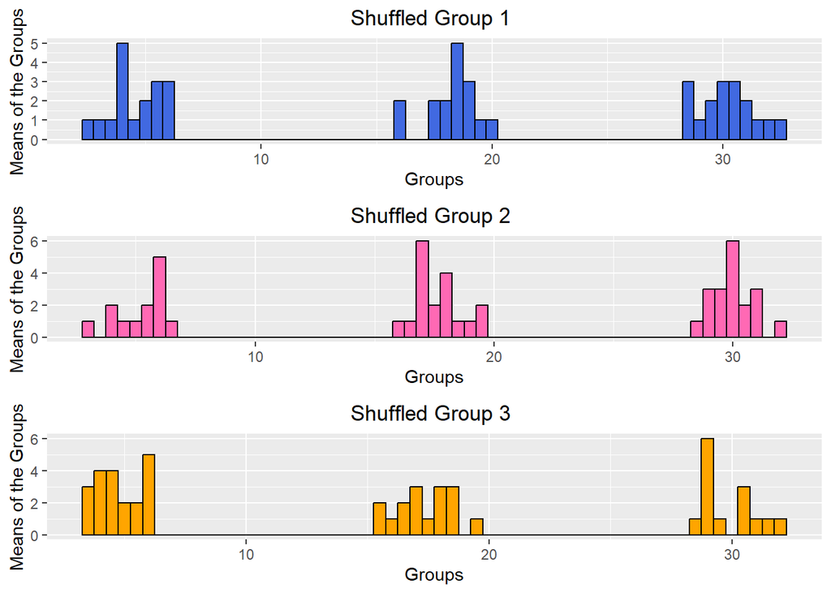

```r
# Reshuffled means plots ------------------------------------------------------

y <- sim_df(c(18, 5, 30)) # create a simulated dataframe
y[2] <- sample(y$Response) # shuffle the Response variable


plot_1 <- ggplot(data = y%>%filter(Group == 1),aes(x = Response)) + # plot group 1
               geom_histogram(binwidth = 0.5,fill = "royalblue", color = "black") +
               labs(title = "Shuffled Group 1 ", x = "Groups", y = "Means of the Groups")+
               theme(plot.title = element_text(hjust=0.5))

plot_2 <- ggplot(data = y%>%filter(Group == 2),aes(x = Response)) + # plot group 2
               geom_histogram(binwidth = 0.5,fill = "hotpink", color = "black") +
               labs(title = "Shuffled Group 2 ", x = "Groups", y = "Means of the Groups") +
               theme(plot.title = element_text(hjust=0.5))

plot_3 <- ggplot(data = y%>%filter(Group == 3),aes(x = Response)) + # plot group 3
               geom_histogram(binwidth = 0.5,fill =  "orange", color = "black") +
               labs(title = "Shuffled Group 3 ", x = "Groups", y = "Means of the Groups") +
               theme(plot.title = element_text(hjust=0.5))


plotList <-list(plot_1, plot_2, plot_3) # compress all the plots into a list
grid.arrange(grobs = plotList) # plot all 3 plots on a grid
```

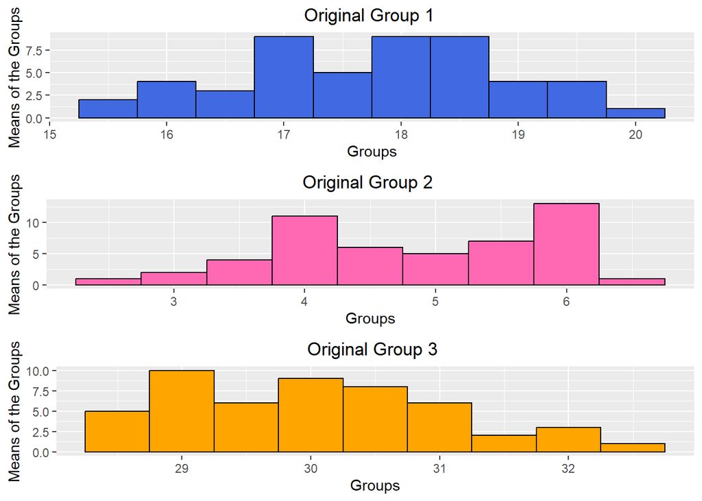

```r
# Original means plot (unshuffled) ------------------------------------------------------

f <- sim_df(c(18, 5, 30))

plot_4 <- ggplot(data = f%>%filter(Group == 1),aes(x = Response)) + # plot group 1
               geom_histogram(binwidth = 0.5,fill = "royalblue", color = "black") +
               labs(title = "Original Group 1 ", x = "Groups", y = "Means of the Groups")+
               theme(plot.title = element_text(hjust=0.5))

plot_5 <- ggplot(data = f%>%filter(Group == 2),aes(x = Response)) + # plot group 2
               geom_histogram(binwidth = 0.5,fill = "hotpink", color = "black") +
               labs(title = "Original Group 2 ", x = "Groups", y = "Means of the Groups") +
               theme(plot.title = element_text(hjust=0.5))

plot_6 <- ggplot(data = f%>%filter(Group == 3),aes(x = Response)) + # plot group 3
               geom_histogram(binwidth = 0.5,fill =  "orange", color = "black") +
               labs(title = "Original Group 3 ", x = "Groups", y = "Means of the Groups") +
               theme(plot.title = element_text(hjust=0.5))


plotList2 <-list(plot_4, plot_5, plot_6) # compress all the plots into a list
grid.arrange(grobs = plotList2) # plot all 3 plots on a grid
```